# Principios y Prácticas de SEM y MLM (5ed)

Tema 2.2 Análisis Factorial Confirmatorio (CFA)

Author

Affiliation

Efraín García Sánchez

CIMCYC — Universidad de Granada

Published

May 15, 2026

> La Investigación como artesanía

# Principios

## Conceptos básicos: `(Bollen, 2026)`

**Medición**

- La medición es un proceso por el cual un concepto se conecta con una o más variables latentes, que a su vez, está ligada con las variables observables .

**Concepto**

- una idea que esenta un fenómeno bajo un término; una serie de cosas que tienen algo en común (e.g., bienestar, personalidad, etc.)

**Variables latentes**

- Representan conceptos en modelos de medición

**Análisis Factorial Confirmatorio (CFA)**

- Un tipo de análisis factorial que se utiliza para evaluar la validez de un modelo teórico específico sobre la estructura de los datos (**Modelo de Medición**).

- Evaluar la teoría o el modelo de medición teórica (e.g, medida, grupos, etc.)
- Controlar por otras fuentes de varianza (e.g., error, invarianza, etc.)
- Desarrollo y validación de instrumentos (e.g, dimensionalidad, fiabilidad, etc.)

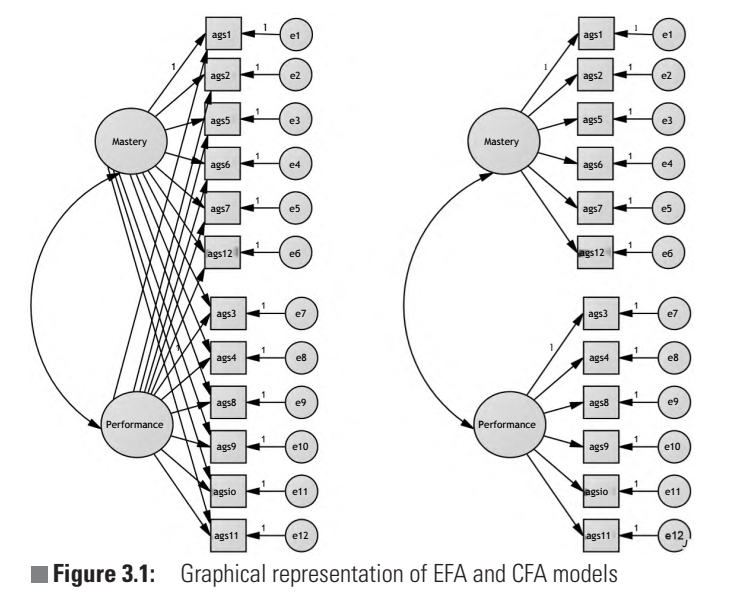

## ¿Cuándo se usan los análisis factoriales exploratorios?

**EFA**

- Orientado por los datos (*data driven*)
- Sin un patrón de relaciones *a priori*
- Fases iniciales de medición (e.g., desarrollo de instrumentos)

**CFA**

- Orientado por la *teoría*
- Patrón de relaciones definido *a priori*
- Fases de validación o confirmación de modelos

**Resultados de EFA/CFA**

- Magnitud de los parámetros (e.g, correlaciones)
- Ajuste entre el fenómeno-teoría-datos

## ¿Análisis factorial Exploratorio o Confirmatorio?

**EFA**

- Generar hipótesis
- Considerar todas las combinaciones posibles
- Inferir modelos
- Examinar medidas o instrumentos

**CFA**

- Confirmar hipótesis
- Controlar de diferentes fuentes de varianza
- Comparar modelos
- Validar medidas para usarlas en SEM

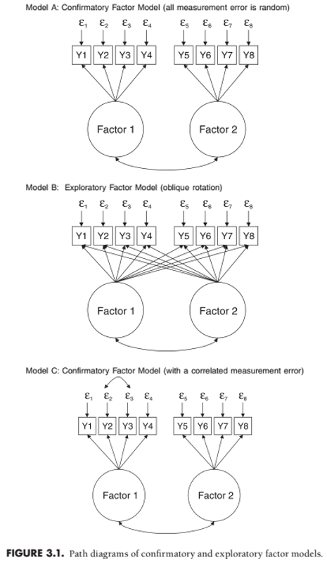

## Conceptos claves en el CFA

- **Cargas factoriales**
  - Regresiones de la Variable Latente (VL) sobre el Indicador
- **Varianza única***:
  - Varianza no es explicada por la VL (error + única)
- **Varianza del factor**
  - La variabilidad en la dispersión del factor
- **Covarianza del error**
  - *correlated uniqueness*, *correlated residuals*, o *correlated errors* (e.g., ítems similares, usando el mismo método, etc.)
- **Correlaciones o covarianza entre factores**
  - Varianza compartida entre los factores

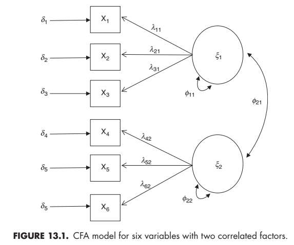

## Representación visual del CFA: diagramas

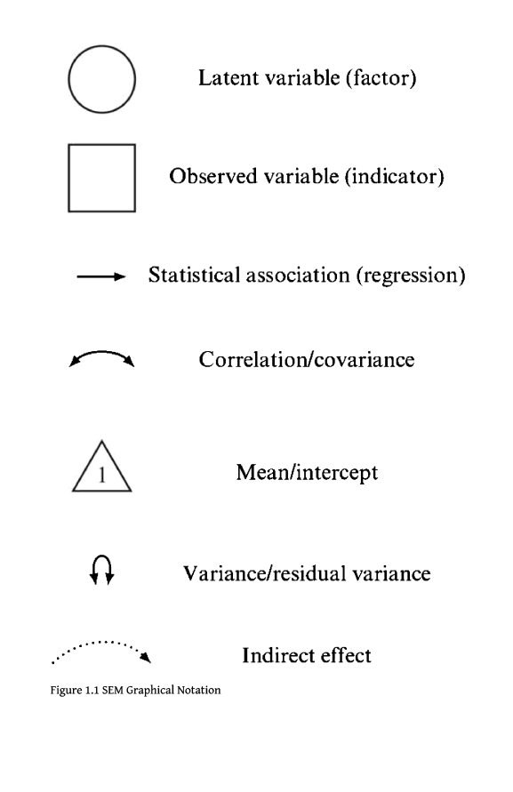

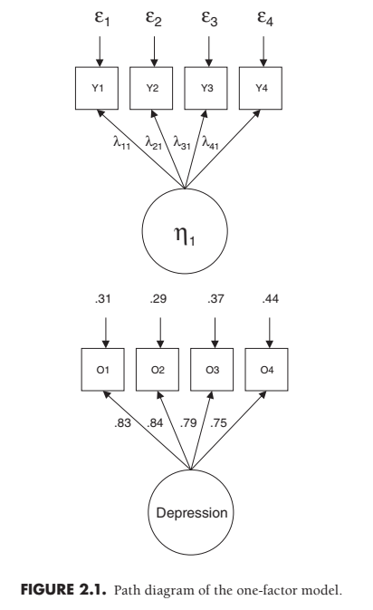

## Representación estadística del CFA: matrices

### Modelo de medición

El CFA evalúa si la estructura factorial propuesta (modelo teórico) puede explicar adecuadamente las covarianzas que observamos entre los ítems (datos).

$$\mathbf{S} \approx \boldsymbol{\Sigma}(\theta)$$

donde:

$$\boldsymbol{\Sigma}(\theta) =
\boldsymbol{\Lambda}
\boldsymbol{\Phi}
\boldsymbol{\Lambda}' +
\boldsymbol{\Theta}$$

- $\boldsymbol{\Lambda}$: cargas factoriales
- $\boldsymbol{\Phi}$: varianzas/covarianzas de los factores
- $\boldsymbol{\Theta}$: varianzas de error

Ejemplo: 6 ítems y 2 factores

$$\boldsymbol{\Lambda} =
\begin{bmatrix}
\lambda_{11} & 0 \\
\lambda_{21} & 0 \\
\lambda_{31} & 0 \\
0 & \lambda_{42} \\
0 & \lambda_{52} \\
0 & \lambda_{62}
\end{bmatrix}$$

$$\boldsymbol{\Phi} =
\begin{bmatrix}
\phi_{11} & \phi_{12} \\
\phi_{21} & \phi_{22}
\end{bmatrix}$$

$$\boldsymbol{\Theta} =
\begin{bmatrix}
\theta_{11} & 0 & 0 & 0 & 0 & 0 \\
0 & \theta_{22} & 0 & 0 & 0 & 0 \\
0 & 0 & \theta_{33} & 0 & 0 & 0 \\
0 & 0 & 0 & \theta_{44} & 0 & 0 \\
0 & 0 & 0 & 0 & \theta_{55} & 0 \\
0 & 0 & 0 & 0 & 0 & \theta_{66}
\end{bmatrix}$$

Los ceros indican restricciones teóricas:  
cada ítem carga solo en el factor especificado.

## Representación estadística del CFA: matrices y diagramas

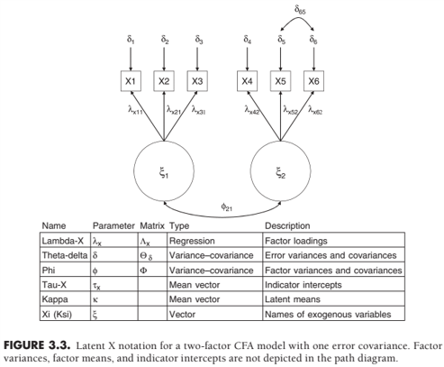

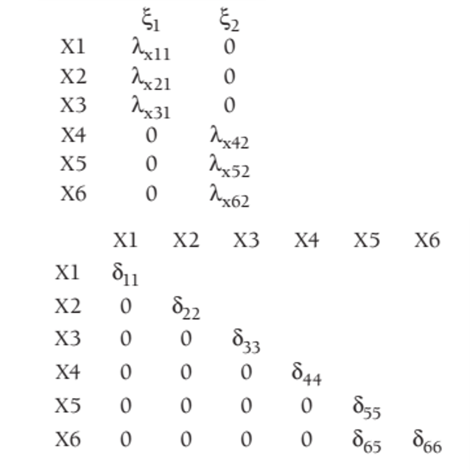

# Práctica

## Procedimiento para un CFA

- **Preparación** de los datos
- **Especificación** del modelo: El modelo teórico
- **Identificación** del modelo: Si hay información suficiente para estimar el modelo
- **Estimación** de los parámetros del modelo: Obtener los parámetros desconocidos a partir de la información conocida (varianzas-covarianzas)
- **Evaluación** del modelo: Determinación del ajuste global y local
- **Reespecificación** del modelo (opcional): Si el modelo no se ajusta adecuadamente, se pueden realizar ajustes basados en la teoría y los datos para mejorar el ajuste del modelo.

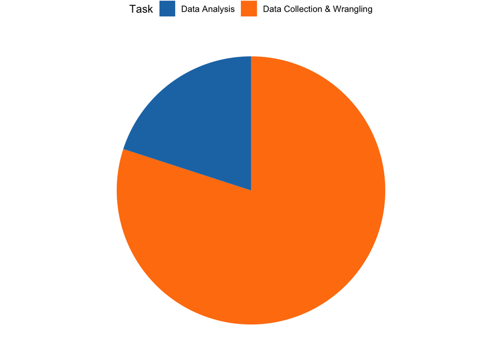

## Preparar el ambiente de trabajo

Instalar los paquetes (si no los tienen instalados)

```r
# install.packages("lavaan")
# install.packages("lavaanExtra")
# install.packages("tidySEM")
# install.packages("semTools")
```

- Cargar los paquetes

```r
library(tidyverse)
library(easystats)
library(lavaanExtra)  # para formatode salida de lavaan
library(tidySEM)      # para formatode salida de lavaan
library(lavaan)       # Para modelos SEM
library(semTools)     # Para fiabilidad y otros relacionadas con SEM
```

## Importar los datos: solo numéricos (recomendado para evitar conflictos con paquetes)

- Importar los datos

```r
data <- readr::read_csv(
  here::here("..", "data",
  "northampton_student_health_data_package",
  "northampton_student_health_numeric.csv"))

glimpse(data)
```

```
Rows: 590
Columns: 61
$ id                             <dbl> 1, 2, 3, 4, 5, 6, 7, 8, 9, 10, 11, 12, …
$ age_group                      <dbl> 1, 1, 1, 1, 1, 1, 2, 4, 1, 1, 1, 1, 1, …
$ gender                         <dbl> 2, 1, 1, 1, 1, 2, 1, 1, 2, 2, 2, 2, 2, …
$ sexual_orientation             <dbl> 1, 2, 1, 3, 1, 1, 1, 1, 1, 1, 1, 1, 1, …
$ ethnicity                      <dbl> 1, 1, 1, 2, 1, 3, 1, 1, 1, 3, 1, 1, 1, …
$ study_mode                     <dbl> 1, 1, 1, 1, 1, 1, 1, 2, 1, 1, 1, 1, 1, …
$ study_level                    <dbl> 3, 3, 3, 3, 2, 6, 4, 3, 1, 2, 1, 1, 1, …
$ living_situation               <dbl> 1, 2, 1, 3, 2, 4, 3, 3, 1, 2, 4, 1, 1, …
$ phys_health                    <dbl> 3, 4, 4, 3, 4, 5, 5, 1, 4, 4, 4, 5, 5, …
$ ment_health                    <dbl> 4, 3, 2, 4, 3, 3, 2, 1, 4, 4, 3, 5, 3, …
$ social_connect                 <dbl> 4, 3, 1, 1, 2, 3, 2, 4, 4, 3, 3, 3, 2, …
$ sitting_weekday_hours          <dbl> 8, 5, 7, 9, NA, 5, 11, 13, 6, 5, 12, 6,…
$ sleep_quality                  <dbl> 8, 7, 4, 7, 2, 5, 3, 8, 7, 2, 9, 7, 3, …
```

[output cut: 48 more lines]

## Crear un subconjunto de datos (para facilitar la demostración)

```r
data_eat <- data |>
  select(eat_fruit, eat_vegetables, eat_calcium,
         eat_red_meat, eat_white_meat, eat_seafood,
         eat_processed_meat, eat_convenience_food, eat_fast_food,
         eat_sweets, eat_snacks)

glimpse(data_eat)
```

```
Rows: 590
Columns: 11
$ eat_fruit            <dbl> 4, 2, 6, 4, 4, 1, 3, 4, 5, 1, 2, 3, 2, 2, 5, 4, 4…
$ eat_vegetables       <dbl> 3, 2, 5, 3, 4, 1, 4, 5, 3, 1, 4, 3, 2, 2, 5, 4, 4…
$ eat_calcium          <dbl> 4, 3, 6, 2, 6, 3, 6, 7, 4, 3, 4, 6, 7, 6, 7, 7, 7…
$ eat_red_meat         <dbl> 2, 1, 0, 3, 2, 2, 0, 2, 4, 3, 4, 1, 0, 3, 3, 2, 2…
$ eat_white_meat       <dbl> 2, 4, 3, 3, 3, 2, 0, 3, 4, 3, 3, 6, 0, 4, 6, 6, 2…
$ eat_seafood          <dbl> 1, 0, 3, 1, 1, 1, 0, 2, 1, 0, 2, 2, 0, 2, 3, 1, 0…
$ eat_processed_meat   <dbl> 1, 6, 0, 1, 1, 2, 0, 3, 2, 1, 1, 1, 0, 3, 1, 4, 2…
$ eat_convenience_food <dbl> 1, 1, 2, 1, 1, 0, 2, 3, 3, 2, 2, 0, 2, 2, 1, 1, 1…
$ eat_fast_food        <dbl> 1, 0, 1, 2, 2, 1, 1, 1, 2, 2, 1, 2, 2, 1, 1, 2, 1…
$ eat_sweets           <dbl> 6, 1, 4, 3, 2, 2, 6, 6, 2, 3, 6, 1, 8, 4, 2, 1, 2…
$ eat_snacks           <dbl> 5, 3, 4, 3, 2, 3, 2, 6, 2, 3, 6, 1, 6, 4, 0, 4, 3…
```

## Práctica: Ajustar un modelo de medición para `habitos de alimentación`

- El concepto podría ser: **hábitos de alimentación**
- Puede verse a través de diferentes dimensiones o factores (e.g., saludable, no saludable, etc.)

```r
# Los factores y las variables
eat_healthy = eat_fruit + eat_vegetables + eat_calcium
eat_meat = eat_red_meat + eat_white_meat + eat_seafood
eat_unhealthy = eat_processed_meat + eat_convenience_food +
  eat_fast_food + eat_sweets + eat_snacks
```

## Examinar los datos

- Examinar que los datos sean adecuados para el análisis
  - Valores legítimos
  - Variabilidad
  - Distribución
  - Outliers

```r
psych::describe(data_eat)
```

```
                     vars   n mean   sd median trimmed  mad min max range  skew
eat_fruit               1 569 2.82 1.65      3    2.84 1.48   0   6     6 -0.09
eat_vegetables          2 573 2.99 1.63      3    3.03 1.48   0   6     6 -0.19
eat_calcium             3 590 4.57 2.04      6    4.64 2.97   0   8     8 -0.25
eat_red_meat            4 590 2.03 1.74      2    1.75 1.48   0   8     8  1.39
eat_white_meat          5 590 3.36 1.93      3    3.30 1.48   0   8     8  0.49
eat_seafood             6 590 1.33 1.49      1    1.06 1.48   0   8     8  2.01
eat_processed_meat      7 590 1.50 1.63      1    1.20 1.48   0   7     7  1.46
eat_convenience_food    8 590 1.46 1.40      1    1.26 1.48   0   8     8  1.57
eat_fast_food           9 590 1.48 1.22      1    1.33 1.48   0   7     7  2.06
eat_sweets             10 590 3.50 2.00      3    3.40 1.48   0   8     8  0.50
eat_snacks             11 590 3.88 1.64      4    4.01 1.48   0   6     6 -0.37
                     kurtosis   se
eat_fruit               -1.19 0.07
eat_vegetables          -1.09 0.07
eat_calcium             -1.19 0.08
eat_red_meat             1.73 0.07
eat_white_meat          -0.25 0.08
eat_seafood              4.68 0.06
eat_processed_meat       1.76 0.07
eat_convenience_food     3.17 0.06
eat_fast_food            6.23 0.05
eat_sweets              -0.79 0.08
eat_snacks              -0.47 0.07
```

## Examinar las correlaciones entre las variables

- Examinar las correlaciones
- Inspeccionar correlaciones y distribuciones

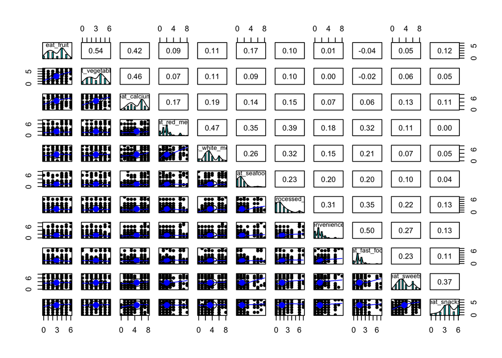

```r
data_eat |>
  psych::pairs.panels()
```

## Examinar las correlaciones entre las variables

- Inspeccionar correlaciones

```r
data_eat_cor <- data_eat |>
  correlation::correlation()
```

- Atención si son muy altas ($r > .8$) o muy bajas ($r < .3$)

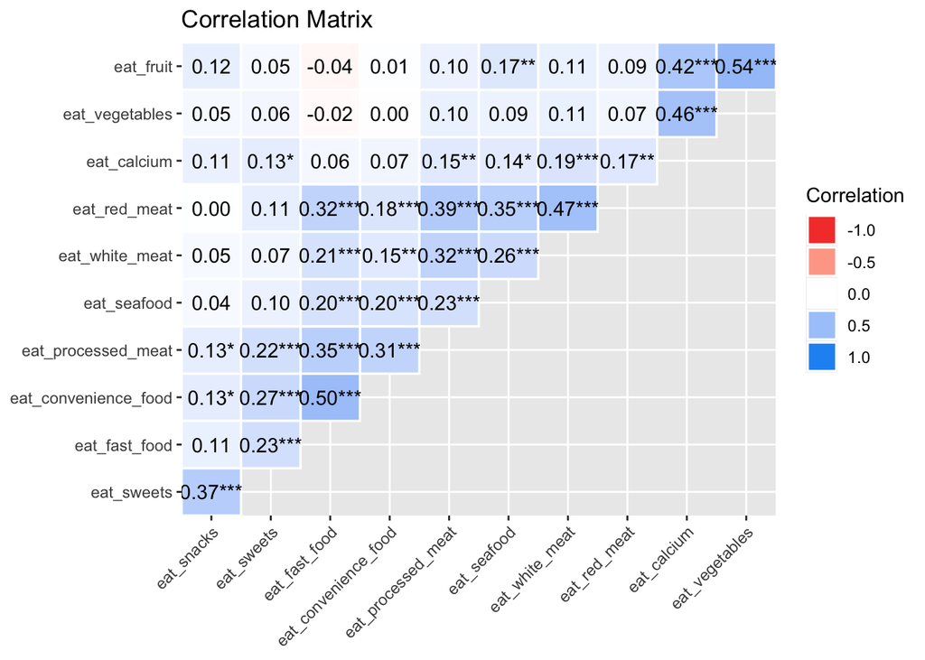

```r
data_eat_cor |>
  summary() |>
  plot() +
  theme(axis.text.x = element_text(angle = 45, hjust = 1)) # para que no se solape el texto en el eje X
```

## Especificación del modelo: conceptual

- Teoría
- Definir las relaciones que serán modeladas
  - Cargas factoriales
  - Varianzas
  - Covarianzas

## Especificación del modelo: lavaan (sintaxis)

```r
m_eat <- 'eat_healthy =~ eat_fruit + eat_vegetables + eat_calcium
              eat_unhealthy =~ eat_processed_meat + eat_convenience_food + eat_fast_food +  + eat_sweets + eat_snacks
              eat_meat =~ eat_red_meat + eat_white_meat + eat_seafood'
```

- Sintaxis o gramática de [lavaan](https://lavaan.ugent.be/tutorial/cfa.html)

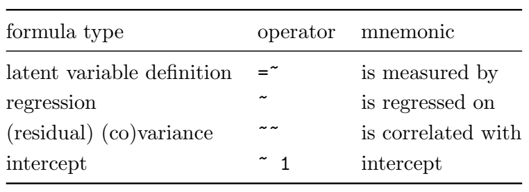

## Identificación estadística del modelo

- Estimación de parámetros (desconocidos) a partir de información conocida (var-cov)
- Un modelo está identificado si hay suficiente información para estimar los parámetros

**Regla:**

- Número de parámetros a estimar no deben exceder la cantidad de información disponible (var-cov)

**¿Cómo se sabe?**

- En función de los grados de libertad (basado en los parámetros, no la muestra)
- Si el modelo está subidentificado, no se puede estimar aunque tenga una muestra grande
- Diferencia entre los parámetros conocidos (p) y desconocidos (q)
  - $df = p - q$
  - Subidentificado $df < 0$ (**No** se puede estimar). Ej. un punto (muchas líneas)
  - Identificado $df = 0$ (se puede estimar) ej. dos puntos (una línea reacta)
  - Sobreidentificado $df > 0$ (se puede estimar) ej. muchos puntos (una línea con más información)

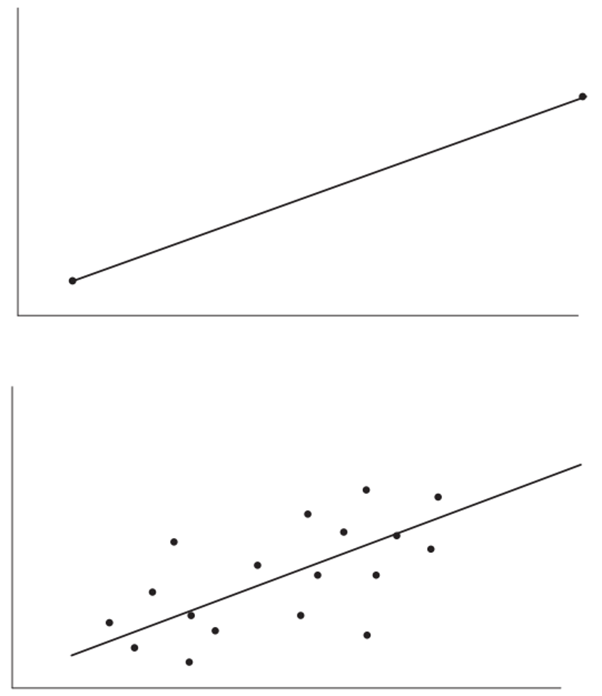

## Identificación estadística del modelo

- Información conocida $p*(p+1)/2$

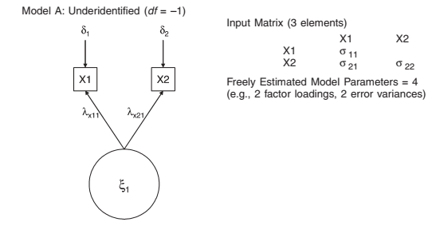

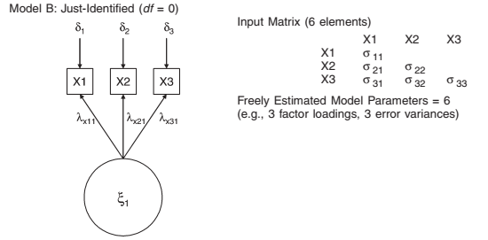

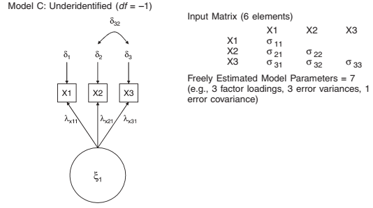

## Identificación estadística

- Tener suficiente información para estimar el modelo teórico
- Indicadores $p = 11$
- Número de parámetros conocidos (existentes en los datos)
  - $11*(11+1)/2 = 66$ [*11 varianzas y 55 covarianzas*]
- Parametros a estimar (desconocidos)
  - $11_{var} + 11_{var.err} + 3_{cov} = 25$
- Grados de libertad
  - $df = 66 - 25 = 41$
- El modelo está sobre identificado
  - Se puede estimar correctamente

## Identificación empírica del modelo

- Tener suficiente información en los datos para estimar el modelo
- Puede estar identificado estadísticamente, pero no empíricamente
  - Especificación del modelo
  - Características de la matriz de *var-cov*

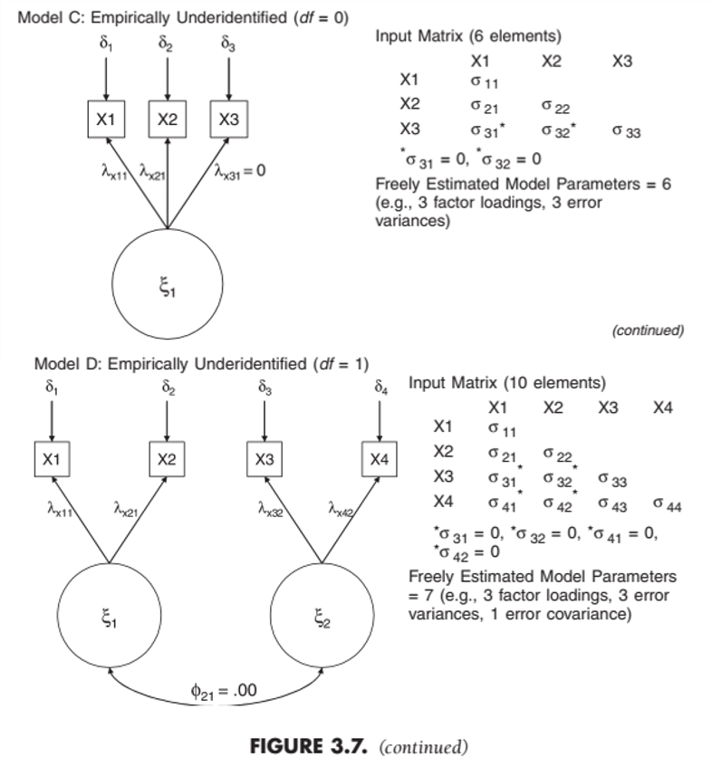

## ¿Cómo se puede identificar un modelo?

- Especificación del modelo (puede variar)
  - Al menos tres indicadores por VL
  - Cada indicador carga en un sólo factor
  - Errores residuales no están correlacionados
- Las variables latentes deben estar escaladas
  - Fijar la varianza a 1 (Unit Variance Identification-UVI)
  - Fijar la métrica de la VL con un indicador (Unit Loading Identification-ULI)

**Si hay problemas de identificación**

- Re-especificar el modelo
  - Simplificar el modelo (eliminar parámetros a estimar)
  - Fijar o constreñir parámetros
- Aumentar los grados de libertad
  - Añadir variables (¡Cuidado!)
- Verificar los datos
  - Problemas con las matrices var-cov (colinealidad)
  - Muestras pequeñas y modelos complejos
  - Casos extremos o de influencia
  - Casos Heywood (varianzas negativas)(¡Cuidado!)

## Estimar los parámetros del modelo

- Estimaciones para cada parámetro
  - produce matriz de var-cov del modelo vs. matriz de var-cov datos
- Estimadores
  - Maximum Likelihood
    - Procesos iterativos
    - Minimizar las diferencias (var-cov del modelo vs. datos)
    - Maximizar las posibilidades de inferir para la población (encontrar parámetros que reproduzcan los datos)
    - Convergencia (obtiene soluciones apropiadas)
  - Requiere muestras grandes y susceptible de problemas de convergencia

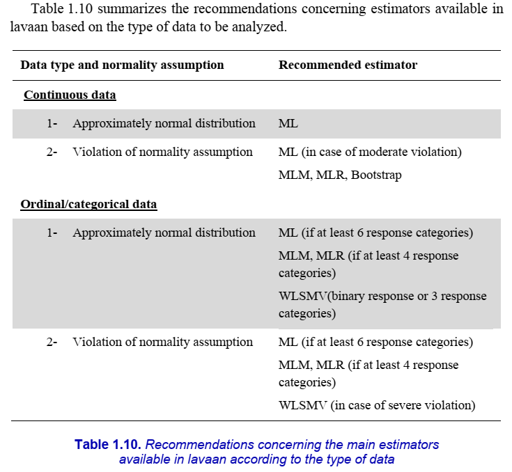

“Gana & Broc (2019). Structural equation modeling with lavaan”

## Estimación de los parámetros: `lavaan::cfa()`

```r
# Especificar el modelo
m_eat <- 'eat_healthy =~ eat_fruit + eat_vegetables + eat_calcium
              eat_unhealthy =~ eat_processed_meat + eat_convenience_food + eat_fast_food
              eat_meat =~ eat_red_meat + eat_white_meat + eat_seafood + eat_sweets + eat_snacks
              '

# Estimar el modelo
m_eat_fit <- lavaan::cfa(model = m_eat,
                         data = data_eat)
```

## Estimación de los parámetros: `lavaan::cfa()`

- Ver el resultado

```r
# resumen del modelo
lavaan::summary(m_eat_fit,
        standardized = TRUE)  # muestra los coeficientes estandarizados
```

```
lavaan 0.6-21 ended normally after 45 iterations

  Estimator                                         ML
  Optimization method                           NLMINB
  Number of model parameters                        25

                                                  Used       Total
  Number of observations                           561         590

Model Test User Model:

  Test statistic                               209.141
  Degrees of freedom                                41
  P-value (Chi-square)                           0.000

Parameter Estimates:

  Standard errors                             Standard
  Information                                 Expected
  Information saturated (h1) model          Structured

Latent Variables:
                   Estimate  Std.Err  z-value  P(>|z|)   Std.lv  Std.all
  eat_healthy =~
    eat_fruit         1.000                               1.169    0.715
    eat_vegetables    1.025    0.094   10.858    0.000    1.197    0.744
    eat_calcium       1.018    0.096   10.626    0.000    1.190    0.593
  eat_unhealthy =~
    eat_procssd_mt    1.000                               0.903    0.551
    eat_convnnc_fd    0.986    0.103    9.602    0.000    0.890    0.647
    eat_fast_food     0.983    0.101    9.760    0.000    0.887    0.728
  eat_meat =~
    eat_red_meat      1.000                               1.236    0.710
    eat_white_meat    0.915    0.094    9.717    0.000    1.130    0.589
    eat_seafood       0.608    0.068    8.899    0.000    0.751    0.509
    eat_sweets        0.381    0.083    4.617    0.000    0.471    0.238
    eat_snacks        0.145    0.066    2.212    0.027    0.179    0.112

Covariances:
                   Estimate  Std.Err  z-value  P(>|z|)   Std.lv  Std.all
  eat_healthy ~~
    eat_unhealthy     0.060    0.062    0.965    0.335    0.057    0.057
    eat_meat          0.366    0.092    3.985    0.000    0.253    0.253
  eat_unhealthy ~~
    eat_meat          0.715    0.097    7.335    0.000    0.641    0.641

Variances:
                   Estimate  Std.Err  z-value  P(>|z|)   Std.lv  Std.all
   .eat_fruit         1.305    0.136    9.572    0.000    1.305    0.489
   .eat_vegetables    1.159    0.136    8.516    0.000    1.159    0.447
   .eat_calcium       2.614    0.196   13.350    0.000    2.614    0.649
   .eat_procssd_mt    1.870    0.135   13.854    0.000    1.870    0.697
   .eat_convnnc_fd    1.098    0.094   11.737    0.000    1.098    0.581
   .eat_fast_food     0.697    0.076    9.156    0.000    0.697    0.470
   .eat_red_meat      1.506    0.160    9.436    0.000    1.506    0.497
   .eat_white_meat    2.400    0.187   12.841    0.000    2.400    0.653
   .eat_seafood       1.616    0.113   14.252    0.000    1.616    0.741
   .eat_sweets        3.704    0.227   16.335    0.000    3.704    0.943
   .eat_snacks        2.557    0.153   16.662    0.000    2.557    0.988
    eat_healthy       1.366    0.178    7.651    0.000    1.000    1.000
    eat_unhealthy     0.815    0.138    5.913    0.000    1.000    1.000
    eat_meat          1.527    0.205    7.442    0.000    1.000    1.000
```

## Otros estimadores ([lavaan](https://lavaan.ugent.be/tutorial/est.html))

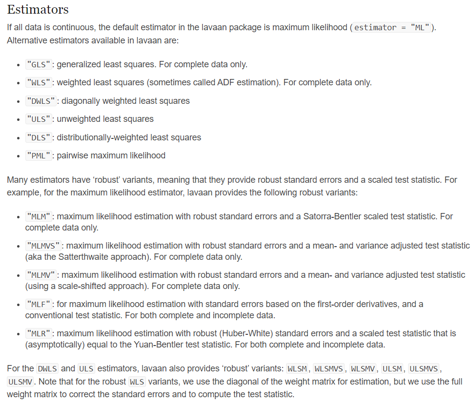

## Representación gráfica del modelo

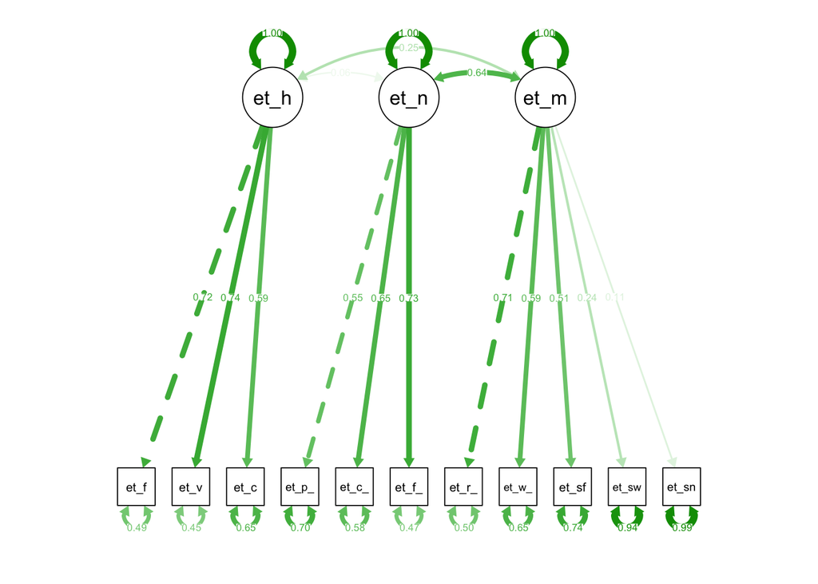

```r
semPlot::semPaths(m_eat_fit,
                  what = "std")
```

## Representación gráfica del modelo (ajustado)

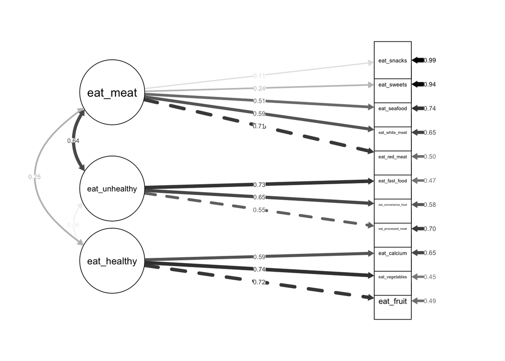

```r
semPlot::semPaths(m_eat_fit,
                  what = "std",
                  layout = "tree2",
                  rotation = 2, style = "lisrel",
                  edge.color = "black",
                  sizeLat = 14,
                  curve = 2.5,
                  sizeMan = 8,
                  nCharNodes = 0)
```

## Evaluar el modelo: Ajuste global

- Matriz del modelo = Matriz de los datos (caso ideal)
  - $\chi~2$ con $p > .05$ ¡Cuidado!
- RMSEA (*root mean square error of approximation*)
  - error del modelo con respecto de la población
- SRMR (*Standardized Root Mean square Residual*)
- CFI (Comparative Fit Index)
  - Compara el modelo con un modelo de base (Nulo)
- TLI (Tucker Lewis Index)
  - Corrección por la complejidad del modelo

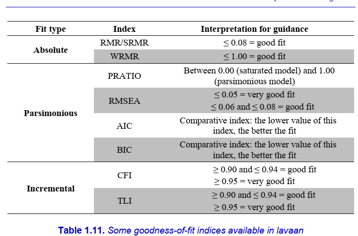

> Litze Hu & Peter M. Bentler (1999) Cutoff criteria for fit indexes in covariance structure analysis: Conventional criteria versus new alternatives, Structural Equation Modeling: A Multidisciplinary Journal, 6:1, 1-55, DOI: 10.1080/10705519909540118

> Browne, M. W., & Cudeck, R. (1993). Alternative ways of assessing model fit. In K. A. Bollen and J. S. Long (Eds.), Testing structural equation models (pp. 136-162). Newbury Park, CA: Sage.

## Evaluación del modelo: todos

```r
lavaan::fitmeasures(m_eat_fit,
                    output = "text")
```

```
Model Test User Model:

  Test statistic                               209.141
  Degrees of freedom                                41
  P-value                                        0.000

Model Test Baseline Model:

  Test statistic                              1183.074
  Degrees of freedom                                55
  P-value                                        0.000

User Model versus Baseline Model:

  Comparative Fit Index (CFI)                    0.851
  Tucker-Lewis Index (TLI)                       0.800
  Bentler-Bonett Non-normed Fit Index (NNFI)     0.800
  Bentler-Bonett Normed Fit Index (NFI)          0.823
  Parsimony Normed Fit Index (PNFI)              0.614
  Bollen's Relative Fit Index (RFI)              0.763
  Bollen's Incremental Fit Index (IFI)           0.853
  Relative Noncentrality Index (RNI)             0.851

Loglikelihood and Information Criteria:

  Loglikelihood user model (H0)             -11314.725
  Loglikelihood unrestricted model (H1)     -11210.154

  Akaike (AIC)                               22679.449
  Bayesian (BIC)                             22787.692
  Sample-size adjusted Bayesian (SABIC)      22708.330

Root Mean Square Error of Approximation:

  RMSEA                                          0.085
  90 Percent confidence interval - lower         0.074
  90 Percent confidence interval - upper         0.097
  P-value H_0: RMSEA <= 0.050                    0.000
  P-value H_0: RMSEA >= 0.080                    0.794

Standardized Root Mean Square Residual:

  RMR                                            0.218
  RMR (No Mean)                                  0.218
  SRMR                                           0.073

Other Fit Indices:

  Hoelter Critical N (CN) alpha = 0.05         153.743
  Hoelter Critical N (CN) alpha = 0.01         175.222

  Goodness of Fit Index (GFI)                    0.933
  Adjusted Goodness of Fit Index (AGFI)          0.893
  Parsimony Goodness of Fit Index (PGFI)         0.580

  McDonald Fit Index (MFI)                       0.861

  Expected Cross-Validation Index (ECVI)         0.462
```

## Evaluación del modelo: algunos indicadores

```r
# Estadísticos de ajuste
lavaan::fitmeasures(m_eat_fit,
                    fit.measures =  c("cfi", "tli", "srmr",
                                      "rmsea", "rmsea.ci.lower", "rmsea.ci.upper") # seleccionar
                    )
```

```
           cfi            tli           srmr          rmsea rmsea.ci.lower
         0.851          0.800          0.073          0.085          0.074
rmsea.ci.upper
         0.097
```

## Evaluar el modelo: algunos indicadores

```r
lavaanExtra::nice_fit(m_eat_fit) |>
  display()
```

| Model | chisq | df | chi2.df | pvalue | cfi | tli | rmsea | rmsea.ci.lower | rmsea.ci.upper | srmr | aic | bic |
| --- | --- | --- | --- | --- | --- | --- | --- | --- | --- | --- | --- | --- |
| Model 1 | 209.14 | 41 | 5.10 | 0 | 0.85 | 0.80 | 0.09 | 0.07 | 0.10 | 0.07 | 22679.45 | 22787.69 |

## Interpretación general [effectsize::interpret()](https://easystats.github.io/effectsize/reference/interpret_gfi.html)

```r
effectsize::interpret(m_eat_fit) |>
  effectsize::display()
```

| Name | Value | Threshold | Interpretation |
| --- | --- | --- | --- |
| GFI | 0.93 | 0.95 | poor |
| AGFI | 0.89 | 0.90 | poor |
| NFI | 0.82 | 0.90 | poor |
| NNFI | 0.80 | 0.90 | poor |
| CFI | 0.85 | 0.90 | poor |
| RMSEA | 0.09 | 0.05 | poor |
| SRMR | 0.07 | 0.08 | satisfactory |
| RFI | 0.76 | 0.90 | poor |
| PNFI | 0.61 | 0.50 | satisfactory |
| IFI | 0.85 | 0.90 | poor |

## Evaluar el modelo: Ajuste local en las cargas factoriales

- Verificar que se tiene un resultado apropiado
  - El modelo converge apropiadamente
  - Parámetros estimados inadmisibles
    - Varianzas estandarizadas > 1
    - Varianzas < 0 (Heywood cases)
    - $R^2 < 0$
    - Parámetros inconsistentes con la teoría
- Verificar para cada parámetro
  - Tamaño del efecto (e.g., cargas factoriales)
  - Test de significancia estadística
  - $R^2$ sustantivo

```r
parameters::parameters(m_eat_fit, standardize = TRUE) |>
  parameters::display()
```

# Loading

| Link | Coefficient | SE | 95% CI | z | p |
| --- | --- | --- | --- | --- | --- |
| eat_healthy =~ eat_fruit | 0.72 | 0.04 | (0.64, 0.79) | 19.96 | < .001 |
| eat_healthy =~ eat_vegetables | 0.74 | 0.04 | (0.67, 0.81) | 20.79 | < .001 |
| eat_healthy =~ eat_calcium | 0.59 | 0.04 | (0.52, 0.67) | 16.06 | < .001 |
| eat_unhealthy =~ eat_processed_meat | 0.55 | 0.04 | (0.47, 0.63) | 14.12 | < .001 |
| eat_unhealthy =~ eat_convenience_food | 0.65 | 0.04 | (0.58, 0.72) | 17.65 | < .001 |
| eat_unhealthy =~ eat_fast_food | 0.73 | 0.04 | (0.66, 0.80) | 20.48 | < .001 |
| eat_meat =~ eat_red_meat | 0.71 | 0.04 | (0.64, 0.78) | 19.11 | < .001 |
| eat_meat =~ eat_white_meat | 0.59 | 0.04 | (0.51, 0.67) | 15.08 | < .001 |
| eat_meat =~ eat_seafood | 0.51 | 0.04 | (0.43, 0.59) | 12.34 | < .001 |
| eat_meat =~ eat_sweets | 0.24 | 0.05 | (0.14, 0.33) | 4.95 | < .001 |
| eat_meat =~ eat_snacks | 0.11 | 0.05 | (0.01, 0.21) | 2.25 | 0.025 |

# Correlation

| Link | Coefficient | SE | 95% CI | z | p |
| --- | --- | --- | --- | --- | --- |
| eat_healthy eat_unhealthy | 0.06 | 0.06 | (-0.06, 0.17) | 0.97 | 0.331 |
| eat_healthy eat_meat | 0.25 | 0.06 | (0.14, 0.37) | 4.37 | < .001 |
| eat_unhealthy eat_meat | 0.64 | 0.05 | (0.55, 0.74) | 13.34 | < .001 |

## Evaluación del modelo: Ajuste local en los `residual correlations`

- Valores absolutos > |.10| indican posible desajuste local

```r
residuos_correlaciones <- lavaan::residuals(m_eat_fit,
                                            type = "cor.bentler")

# visualizar
residuos_correlaciones
```

```
$type
[1] "cor.bentler"

$cov
                     et_frt et_vgt et_clc et_pr_ et_cn_ et_fs_ et_rd_ et_wh_
eat_fruit             0.000
eat_vegetables        0.006  0.000
eat_calcium          -0.013  0.002  0.000
eat_processed_meat    0.074  0.082  0.128  0.000
eat_convenience_food -0.008 -0.022  0.054 -0.033  0.000
eat_fast_food        -0.062 -0.065  0.015 -0.044  0.048  0.000
eat_red_meat         -0.044 -0.080  0.040  0.139 -0.097 -0.015  0.000
eat_white_meat        0.006 -0.014  0.068  0.112 -0.075 -0.080  0.047  0.000
eat_seafood           0.079  0.008  0.077  0.047 -0.012 -0.024  0.002 -0.013
eat_sweets            0.008  0.009  0.075  0.128  0.182  0.118 -0.059 -0.098
eat_snacks            0.091  0.015  0.064  0.068  0.079  0.055 -0.082 -0.043
                     et_sfd et_swt et_snc
eat_fruit
eat_vegetables
eat_calcium
eat_processed_meat
eat_convenience_food
eat_fast_food
eat_red_meat
eat_white_meat
eat_seafood           0.000
eat_sweets           -0.017  0.000
eat_snacks           -0.014  0.326  0.000
```

```r
# para verlos como una lista

as.data.frame(as.table(residuos_correlaciones$cov)) |> # convierto en lista
  mutate(
    Var1 = as.character(Var1),
    Var2 = as.character(Var2),
    value = abs(Freq)) |> # creo una variable con valor absoluto
   filter(Var1 < Var2) |> # elimino pares duplicados
  filter(value > .10) |>  # selecciono valor absoluto > .10
  arrange(desc(value)) # orden descendente
```

```
                  Var1               Var2      Freq     value
1           eat_snacks         eat_sweets 0.3262588 0.3262588
2 eat_convenience_food         eat_sweets 0.1817426 0.1817426
3   eat_processed_meat       eat_red_meat 0.1387992 0.1387992
4   eat_processed_meat         eat_sweets 0.1277939 0.1277939
5          eat_calcium eat_processed_meat 0.1275488 0.1275488
6        eat_fast_food         eat_sweets 0.1181858 0.1181858
7   eat_processed_meat     eat_white_meat 0.1120399 0.1120399
```

## Evaluación del modelo: Ajuste local en los residuos estandarizados

- Valores absolutos |residuo estandarizado| > 2; indican desajuste local
  - $residuals > 2.58$ que corresponde $p < .01$
  - $residuals > 3.29$ que corresponde $p < .001$
  - Cuidado: En muestras grandes, los errores pueden ser “significativos” pero irrelevantes
- La relación entre los ítems en los datos difiere del modelo que se ha especificado
  - Valor positivo (*underpredicted*)
    - La relación observada en los datos es mayor que la que el modelo predice (modelo subestima la relación)
  - Valor negativo *overpredicted*
    - La relación observada es menor que la que el modelo predice (modelo sobreestima la relación)

```r
residuos_estandarizados <- lavaan::residuals(m_eat_fit,
                                            type = "standardized")

residuos_estandarizados
```

```
$type
[1] "standardized"

$cov
                     et_frt et_vgt et_clc et_pr_ et_cn_ et_fs_ et_rd_ et_wh_
eat_fruit             0.000
eat_vegetables        2.401  0.000
eat_calcium          -2.438  0.375  0.000
eat_processed_meat    2.053  2.280  3.335  0.000
eat_convenience_food -0.245 -0.736  1.533 -2.194  0.000
eat_fast_food        -2.157 -2.386  0.453 -4.190  5.473  0.000
eat_red_meat         -1.605 -3.078  1.210  4.758 -4.566 -0.811  0.000
eat_white_meat        0.199 -0.453  1.940  3.551 -2.806 -3.329  3.811  0.000
eat_seafood           2.244  0.231  2.100  1.468 -0.401 -0.867  0.171 -0.584
eat_sweets            0.198  0.222  1.864  3.647  4.778  3.313 -2.901 -3.545
eat_snacks            2.193  0.371  1.576  1.917  2.083  1.527 -3.714 -1.468
                     et_sfd et_swt et_snc
eat_fruit
eat_vegetables
eat_calcium
eat_processed_meat
eat_convenience_food
eat_fast_food
eat_red_meat
eat_white_meat
eat_seafood           0.000
eat_sweets           -0.526  0.000
eat_snacks           -0.432  7.613  0.000
```

```r
as.data.frame(as.table(residuos_estandarizados$cov)) |> # convierto en lista
  mutate(
    Var1 = as.character(Var1),
    Var2 = as.character(Var2),
    value = abs(Freq)) |> # creo una variable con valor absoluto
   filter(Var1 < Var2) |> # elimino pares duplicados
  filter(value > 2.57) |>  # selecciono valor absoluto > .257 (corresponde a p < .01)
  arrange(desc(value)) # orden descendente
```

```
                   Var1               Var2      Freq    value
1            eat_snacks         eat_sweets  7.613298 7.613298
2  eat_convenience_food      eat_fast_food  5.472902 5.472902
3  eat_convenience_food         eat_sweets  4.778223 4.778223
4    eat_processed_meat       eat_red_meat  4.758374 4.758374
5  eat_convenience_food       eat_red_meat -4.566270 4.566270
6         eat_fast_food eat_processed_meat -4.189681 4.189681
7          eat_red_meat     eat_white_meat  3.810566 3.810566
8          eat_red_meat         eat_snacks -3.713951 3.713951
9    eat_processed_meat         eat_sweets  3.647068 3.647068
10   eat_processed_meat     eat_white_meat  3.550660 3.550660
11           eat_sweets     eat_white_meat -3.545143 3.545143
12          eat_calcium eat_processed_meat  3.335392 3.335392
13        eat_fast_food     eat_white_meat -3.329487 3.329487
14        eat_fast_food         eat_sweets  3.313310 3.313310
15         eat_red_meat     eat_vegetables -3.077965 3.077965
16         eat_red_meat         eat_sweets -2.901492 2.901492
17 eat_convenience_food     eat_white_meat -2.806157 2.806157
```

## Evaluación del modelo: Ajuste local en los `índices de modificación`

- Inspeccionar
  - Modification indices (MI)
    - Aumento en $\chi^2$ al adicionar un parámetro
    - $MI > 3.84$ el parámetro mejora $p < .05$
    - $MI > 10.83$ el parámetro mejora $p < .001$
  - Expected Parameter Change (EPC)
    - valor esperado del parámetro liberado
    - Pequeño $sepc.all < .10$
    - Medio $.10 < sepc.all < .30$
    - Grande $sepc.all > .30$

```r
lavaan::modificationindices(m_eat_fit,
                            sort. = TRUE) |>
  dplyr::filter(mi > 10)
```

```
                    lhs op                  rhs     mi    epc sepc.lv sepc.all
1            eat_sweets ~~           eat_snacks 66.074  1.072   1.072    0.348
2              eat_meat =~   eat_processed_meat 47.527  0.723   0.893    0.545
3  eat_convenience_food ~~        eat_fast_food 39.468  0.665   0.665    0.761
4         eat_unhealthy =~           eat_sweets 31.370  0.963   0.869    0.439
5          eat_red_meat ~~       eat_white_meat 19.969  0.813   0.813    0.428
6  eat_convenience_food ~~         eat_red_meat 17.410 -0.331  -0.331   -0.258
7  eat_convenience_food ~~           eat_sweets 17.142  0.400   0.400    0.198
8           eat_healthy =~   eat_processed_meat 14.453  0.244   0.285    0.174
9    eat_processed_meat ~~        eat_fast_food 14.435 -0.382  -0.382   -0.334
10         eat_red_meat ~~           eat_snacks 13.329 -0.399  -0.399   -0.203
11             eat_meat =~ eat_convenience_food 12.433 -0.338  -0.417   -0.304
12   eat_processed_meat ~~         eat_red_meat 11.795  0.325   0.325    0.194
13       eat_white_meat ~~           eat_sweets 11.793 -0.503  -0.503   -0.169
   sepc.nox
1     0.348
2     0.545
3     0.761
4     0.439
5     0.428
6    -0.258
7     0.198
8     0.174
9    -0.334
10   -0.203
11   -0.304
12    0.194
13   -0.169
```

## Re-especificación del modelo: Teoría-Datos-Práctica

- Entender las causas del desajuste
  - **Teóricas** (mi modelo no capta el fenómeno con los datos disponibles)
  - Naturaleza de los ítems y/o los datos
  - Estadísticas (parámetros omitidos o mal especificados)
- Verificar:
  - Índices de modificación (*MI*) ¡Cuidado!
    - Aumento en $\chi^2$ al adicionar un parámetro
  - Residuos del modelo
    - Discrepancias entre las matrices de `var-cov`
- Cuidado:
  - Re-espeficar no siempre lleva al modelo verdadero
  - Investigación exploratoria: Poca evidencia de las hipótesis iniciales

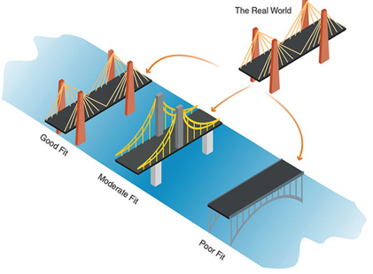

## Re-especificar el modelo

```r
# re-especificar el modelo
m_eat_resp <- '
          eat_healthy =~ eat_fruit + eat_vegetables + eat_calcium
          eat_unhealthy =~ eat_processed_meat + eat_convenience_food + eat_fast_food
          eat_meat =~ eat_red_meat + eat_white_meat + eat_seafood
          eat_sweets_snacks =~ eat_sweets + eat_snacks
          '

# estimar el modelo
m_eat_resp_fit <- lavaan::cfa(m_eat_resp, data = data_eat)

# evaluar el modelo: ajuste global
effectsize::interpret(m_eat_resp_fit)
```

```
    Name      Value Threshold Interpretation
1    GFI 0.96936664      0.95   satisfactory
2   AGFI 0.94679469      0.90   satisfactory
3    NFI 0.91829074      0.90   satisfactory
4   NNFI 0.92472626      0.90   satisfactory
5    CFI 0.94799269      0.90   satisfactory
6  RMSEA 0.05245993      0.05           poor
7   SRMR 0.04825414      0.08   satisfactory
8    RFI 0.88173660      0.90           poor
9   PNFI 0.63445542      0.50   satisfactory
10   IFI 0.94876480      0.90   satisfactory
```

## Comparar los modelos

- Si es significativo indica que el modelo re-especificado mejora el ajuste del modelo original

```r
library(lavaan)
library(semTools)

fit_comp <- semTools::compareFit(m_eat_fit, m_eat_resp_fit)

summary(fit_comp)
```

```
################### Nested Model Comparison #########################

Chi-Squared Difference Test

               Df   AIC   BIC   Chisq Chisq diff   RMSEA Df diff Pr(>Chisq)
m_eat_resp_fit 38 22573 22694  96.668
m_eat_fit      41 22679 22788 209.141     112.47 0.25504       3  < 2.2e-16 ***
---
Signif. codes:  0 '***' 0.001 '**' 0.01 '*' 0.05 '.' 0.1 ' ' 1

####################### Model Fit Indices ###########################
                  chisq df pvalue rmsea   cfi   tli  srmr        aic        bic
m_eat_resp_fit  96.668† 38   .000 .052† .948† .925† .048† 22572.977† 22694.209†
m_eat_fit      209.141  41   .000 .085  .851  .800  .073  22679.449  22787.692

################## Differences in Fit Indices #######################
                           df rmsea    cfi    tli  srmr     aic    bic
m_eat_fit - m_eat_resp_fit  3 0.033 -0.097 -0.125 0.025 106.473 93.483
```

## Reportar los resultados con tablas [tidySEM](https://cjvanlissa.github.io/tidySEM/index.html) (adaptado)

- Sólo con fines orientativos y mostrar cómo se puede reportar los resultados de un CFA con `tidySEM` (adaptado)

```r
tidySEM::table_results(m_eat_resp_fit,
                       columns = c("label", "est_sig_std", "se_std", "pval_std", "confint_std"),
                       digits = 3) |>
  #parameters::display() |>
  filter(grepl(".BY.", label)) |> # para seleccionar cargas factoriales
  mutate(label = str_replace(label,
                             pattern = ".BY.",
                             replacement = " predicted by ")) |>
  knitr::kable(col.names = c("Parámetro", "Factor loadings", "SE", "p", "95% CI"))
```

| Parámetro | Factor loadings | SE | p | 95% CI |
| --- | --- | --- | --- | --- |
| eat_healthy predicted by eat_fruit | 0.714*** | 0.036 | 0.000 | [0.644, 0.784] |
| eat_healthy predicted by eat_vegetables | 0.743*** | 0.036 | 0.000 | [0.673, 0.813] |
| eat_healthy predicted by eat_calcium | 0.594*** | 0.037 | 0.000 | [0.522, 0.666] |
| eat_unhealthy predicted by eat_processed_meat | 0.554*** | 0.038 | 0.000 | [0.478, 0.629] |
| eat_unhealthy predicted by eat_convenience_food | 0.659*** | 0.035 | 0.000 | [0.589, 0.728] |
| eat_unhealthy predicted by eat_fast_food | 0.715*** | 0.034 | 0.000 | [0.647, 0.782] |
| eat_meat predicted by eat_red_meat | 0.744*** | 0.038 | 0.000 | [0.670, 0.818] |
| eat_meat predicted by eat_white_meat | 0.609*** | 0.039 | 0.000 | [0.532, 0.685] |
| eat_meat predicted by eat_seafood | 0.500*** | 0.041 | 0.000 | [0.419, 0.581] |
| eat_sweets_snacks predicted by eat_sweets | 0.821*** | 0.097 | 0.000 | [0.631, 1.010] |
| eat_sweets_snacks predicted by eat_snacks | 0.430*** | 0.061 | 0.000 | [0.311, 0.549] |

## Reportar los resultados con figuras (adaptado)

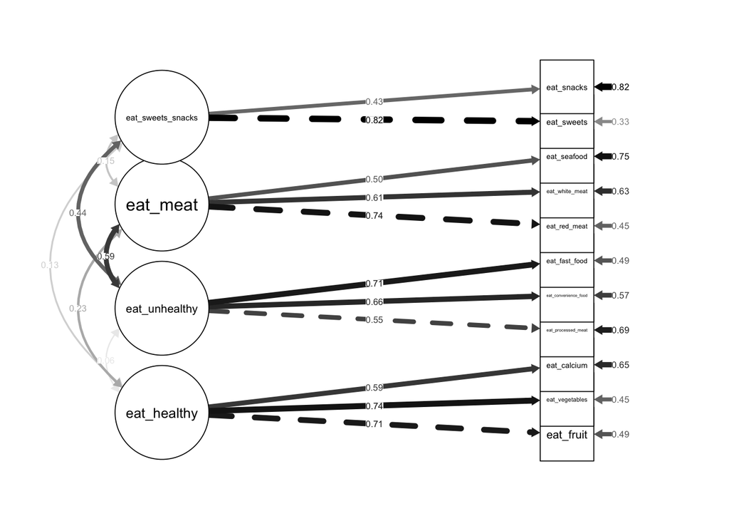

```r
semPlot::semPaths(m_eat_resp_fit,
                  what = "std",
                  layout = "tree2",
                  rotation = 2,
                  style = "lisrel",
                  edge.color = "black",
                  sizeLat = 14,
                  curve = 2.5,
                  sizeMan = 8,
                  nCharNodes = 0)
```

## Fiabilidad: Omega de MacDonald ($\omega$) [(Flora, 2022)](https://journals.sagepub.com/doi/full/10.1177/2515245920951747)

```r
# calcular el omega de Macdonald
semTools::compRelSEM(m_eat_resp_fit,
                     tau.eq = FALSE) # tau.eq = TRUE devuelve el alpha de Cronbach
```

```
$eat_healthy

Composite `eat_healthy` is composed of observed variables:
    eat_fruit, eat_vegetables, eat_calcium
True-score variance is represented by common factor(s):
    eat_healthy
Total variance of composite `eat_healthy` determined from the unrestricted model.
The proportion attributable to "true" scores is its model-based estimate of reliability ("omega"):

[1] 0.716

$eat_unhealthy

Composite `eat_unhealthy` is composed of observed variables:
    eat_processed_meat, eat_convenience_food, eat_fast_food
True-score variance is represented by common factor(s):
    eat_unhealthy
Total variance of composite `eat_unhealthy` determined from the unrestricted model.
The proportion attributable to "true" scores is its model-based estimate of reliability ("omega"):

[1] 0.674

$eat_meat

Composite `eat_meat` is composed of observed variables:
    eat_red_meat, eat_white_meat, eat_seafood
True-score variance is represented by common factor(s):
    eat_meat
Total variance of composite `eat_meat` determined from the unrestricted model.
The proportion attributable to "true" scores is its model-based estimate of reliability ("omega"):

[1] 0.661

$eat_sweets_snacks

Composite `eat_sweets_snacks` is composed of observed variables:
    eat_sweets, eat_snacks
True-score variance is represented by common factor(s):
    eat_sweets_snacks
Total variance of composite `eat_sweets_snacks` determined from the unrestricted model.
The proportion attributable to "true" scores is its model-based estimate of reliability ("omega"):

[1] 0.613
```

# Ejercicio: CFA

## Ejercicio: modelo de bienestar y sustancias

Adapta la práctica anterior para estimar un análisis factorial confirmatorio con el siguiente modelo de medición:

```r
wellbeing =~ ment_health + phys_health + social_connect + sleep_quality
substances =~ caffeine_non_exam + alcohol_freq + nicotine_freq
```

### Instrucciones

1. **Especifica el modelo** en sintaxis de `lavaan`.
2. **Estima el modelo** con `lavaan::cfa()`.
3. **Evalúa el modelo** usando indicadores de ajuste global.
4. **Inspecciona el modelo** revisando cargas factoriales, covarianzas/correlaciones entre factores y posibles desajustes locales.
5. **Extrae conclusiones sustantivas** sobre el modelo de medición.

# Escribir tu respuesta aquí

# Extra: Problemas de convergencia

## ¿Cómo resolver problemas de convergencia?

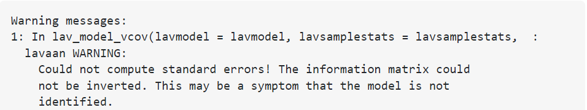

- Fallas en el modelo (e.g, no identificado, errado)
  - Alternativa: Re-especificar (simplificar)
- Fallas en los datos (e.g., casos Heywood, comunalidades > 1, etc.)
  - Correlaciones muy altas o muy bajas; violación de supuestos estadísticos
  - Alternativa: Usar estimadores robustos, bootstrapping, etc.
- Fallas en la muestra
  - Muestras muy pequeñas
  - Alternativa: Aumentar la muestra

## En resumen

- CFA como una forma de evaluar teorías e hipótesis (vs. EFA)
- Proceso
  - Especificar el modelo: Teoría
  - Identificación del modelo: Estadística y empírica
  - Estimación del modelo: estimadores apropiados
  - Evaluación del modelo: ajuste global, local y desajustes
  - Re-especificación: adicionar o eliminar parámetros (¿exploratorio?)
  - Interpretación (teórica, práctica, etc.)